# zalshaye_5

### Data Pre-processing

Find the number of missing values and either remove or omit them

```r
cereals_data <- read.csv("C://Users//Z/Desktop//ML - Assignment 5//Cereals.csv")
cereals<-read.csv("Cereals.csv")
str(cereals_data)
```

```
## 'data.frame':    77 obs. of  16 variables:
##  $ name    : chr  "100%_Bran" "100%_Natural_Bran" "All-Bran" "All-Bran_with_Extra_Fiber" ...
##  $ mfr     : chr  "N" "Q" "K" "K" ...
##  $ type    : chr  "C" "C" "C" "C" ...
##  $ calories: int  70 120 70 50 110 110 110 130 90 90 ...
##  $ protein : int  4 3 4 4 2 2 2 3 2 3 ...
##  $ fat     : int  1 5 1 0 2 2 0 2 1 0 ...
##  $ sodium  : int  130 15 260 140 200 180 125 210 200 210 ...
##  $ fiber   : num  10 2 9 14 1 1.5 1 2 4 5 ...
##  $ carbo   : num  5 8 7 8 14 10.5 11 18 15 13 ...
##  $ sugars  : int  6 8 5 0 8 10 14 8 6 5 ...
##  $ potass  : int  280 135 320 330 NA 70 30 100 125 190 ...
##  $ vitamins: int  25 0 25 25 25 25 25 25 25 25 ...
##  $ shelf   : int  3 3 3 3 3 1 2 3 1 3 ...
##  $ weight  : num  1 1 1 1 1 1 1 1.33 1 1 ...
##  $ cups    : num  0.33 1 0.33 0.5 0.75 0.75 1 0.75 0.67 0.67 ...
##  $ rating  : num  68.4 34 59.4 93.7 34.4 ...
```

```r
sum(is.na(cereals_data))
```

```
## [1] 4
```

To remove any missing value that might be present in the data, type this:

```r
cereals_data <- na.omit(cereals_data)
cereals<-na.omit(cereals)
sum(is.na(cereals_data))
```

```
## [1] 0
```

Convert the names of the breakfast cereals to the row names, as this will later help us in visualising the clusters

```r
rownames(cereals_data) <- cereals_data$name
rownames(cereals) <- cereals$name
```

Drop the name column as it is now just redundant information

```r
cereals_data$name = NULL
cereals$name = NULL
```

The data must be scaled, before measuring any type of distance metric as the variables with higher ranges will significantly influence the distance

```r
cereals_data <- scale(cereals_data[,3:15])
```

we will apply hierarchical clustering to the data using Euclidean distance

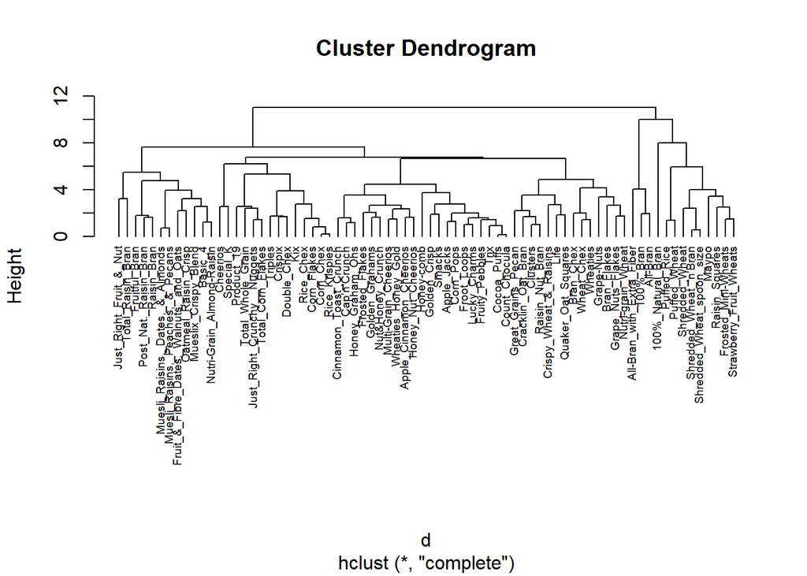

```r
# Dissimilarity matrix
d <- dist(cereals_data, method = "euclidean")

# Hierarchical clustering using Complete Linkage
hc_complete <- hclust(d, method = "complete" )

# Plot the obtained dendrogram
plot(hc_complete, cex = 0.6, hang = -1)
```

Using Agnes to compare the clustering from single linkage, complete linkage, average linkage, and Ward and comparing agglomerative coefficients of each method.

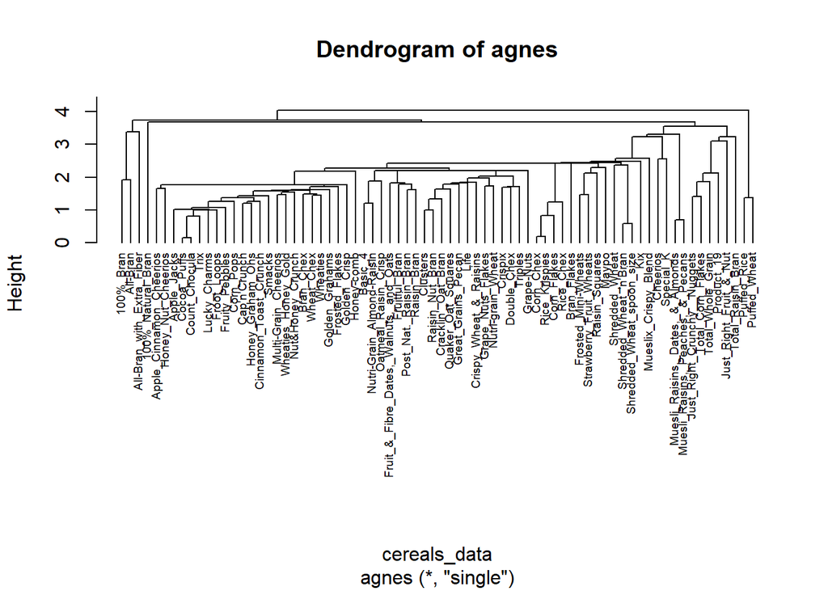

```r
library(cluster)
hc_single <- agnes(cereals_data, method = "single")
pltree(hc_single, cex = 0.6, hang = -1, main = "Dendrogram of agnes")
```

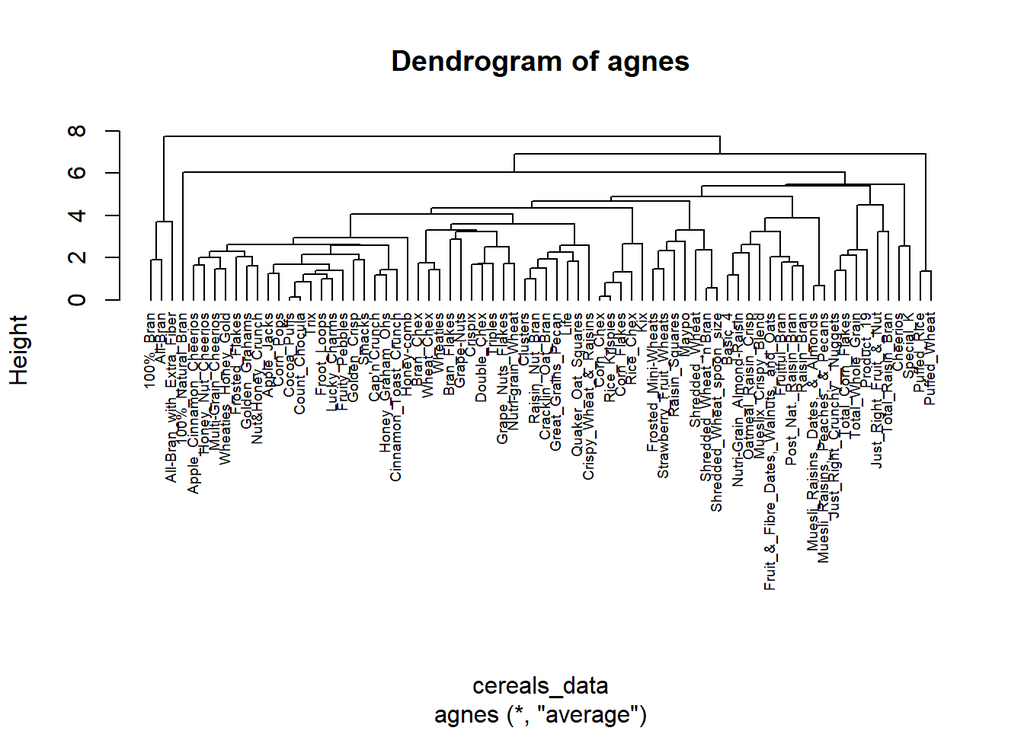

```r
hc_average <- agnes(cereals_data, method = "average")
pltree(hc_average, cex = 0.6, hang = -1, main = "Dendrogram of agnes")
```

We will find the agnes coefficient of all the methods.

```r
# methods to assess
m <- c( "average", "single", "complete", "ward")
names(m) <- c( "average", "single", "complete", "ward")

# function to compute coefficient
ac <- function(x) {
  agnes(cereals_data, method = x)$ac
}

map_dbl(m, ac)
```

```
##   average    single  complete      ward
## 0.7766075 0.6067859 0.8353712 0.9046042
```

The best linkage method is ward with agglomerative coefficient of 0.9046042.

visualizing the dendrogram using wards method:

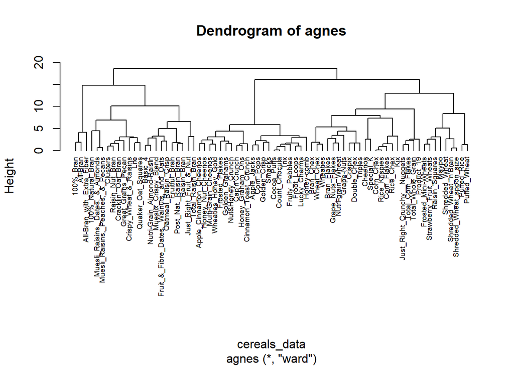

```r
hc_ward <- agnes(cereals_data, method = "ward")
pltree(hc_ward, cex = 0.6, hang = -1, main = "Dendrogram of agnes")
```

In order to identify sub-groups (i.e. clusters), we can cut the dendrogram with cutree():

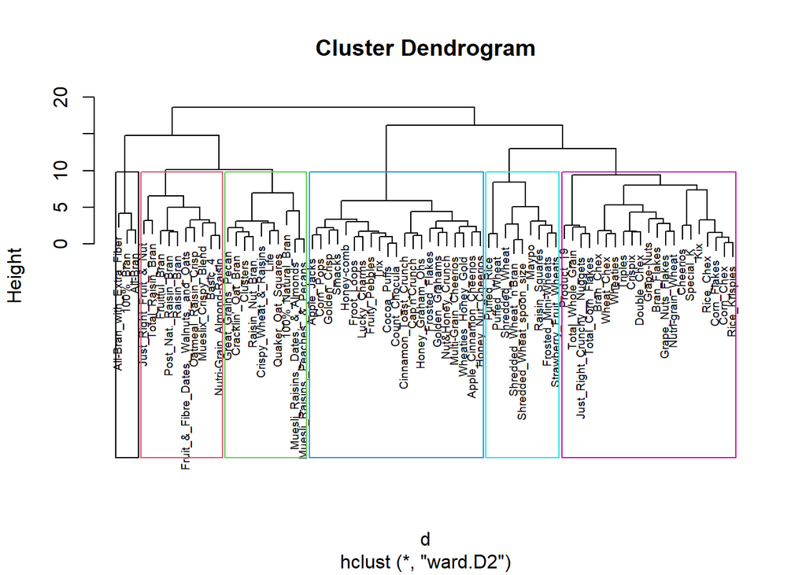

```r
#Create the distance matrix
d <- dist(cereals_data, method = "euclidean")

# Ward's method for Hierarchical clustering
hc_ward_cut <- hclust(d, method = "ward.D2" )

plot(hc_ward_cut, cex=0.6 )
rect.hclust(hc_ward_cut,k=6,border = 1:6)
```

Lets see how many number of records of the data grouped and assigned to clusters:

```r
# Cut tree into 6 groups
sub_grp <- cutree(hc_ward_cut, k = 6)

# Number of members in each cluster
table(sub_grp)
```

```
## sub_grp
##  1  2  3  4  5  6
##  3 10 21 10 21  9
```

Correlation matrix:

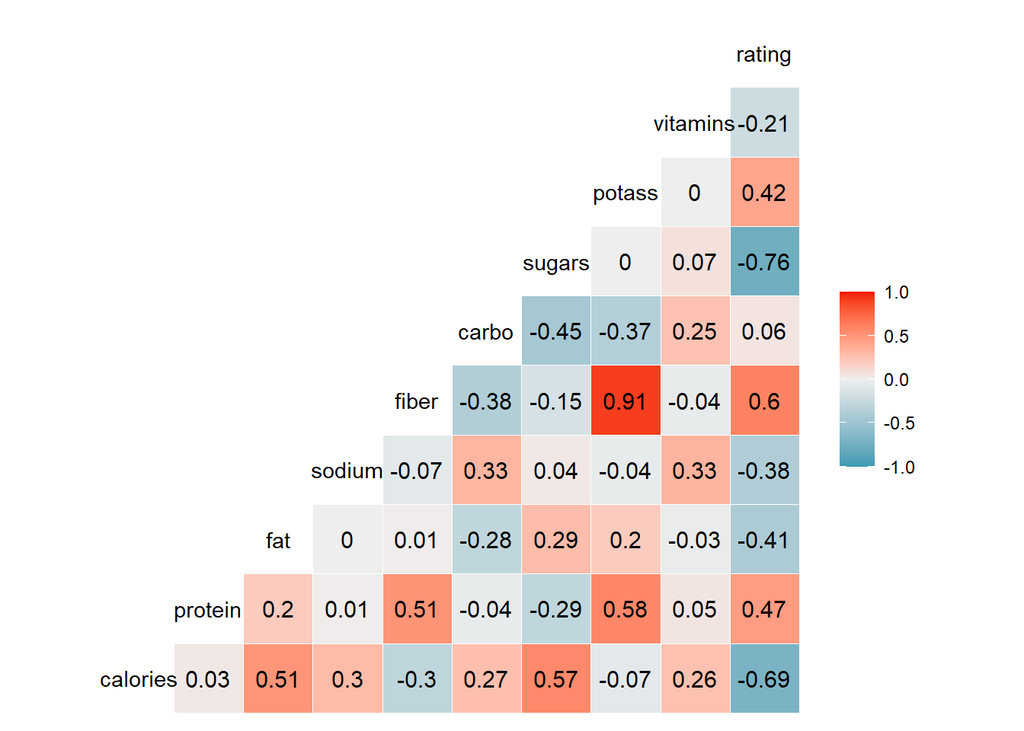

```r
#install.packages("GGally")
cereals %>%
  select(calories, protein, fat, sodium, fiber, carbo, sugars, potass,vitamins,rating) %>%
  ggcorr(palette = "RdBu", label = TRUE, label_round =  2)
```

The correlation matrix helps us in guaging weather strong or weak relation existing between the variables. This will give us a better perspective in deriving descriptive statistics between the variables.

The pvclust( ) function in the pvclust package provides p-values for hierarchical clustering based on multiscale bootstrap resampling. Clusters that are highly supported by the data will have large p values. Interpretation details are provided Suzuki. Be aware that pvclust clusters columns, not rows. Transpose your data before using.

```r
# Ward Hierarchical Clustering with Bootstrapped p values
#install.packages("pvclust")
library(pvclust)
fit.pv <- pvclust(cereals_data, method.hclust="ward.D2",
               method.dist="euclidean")
```

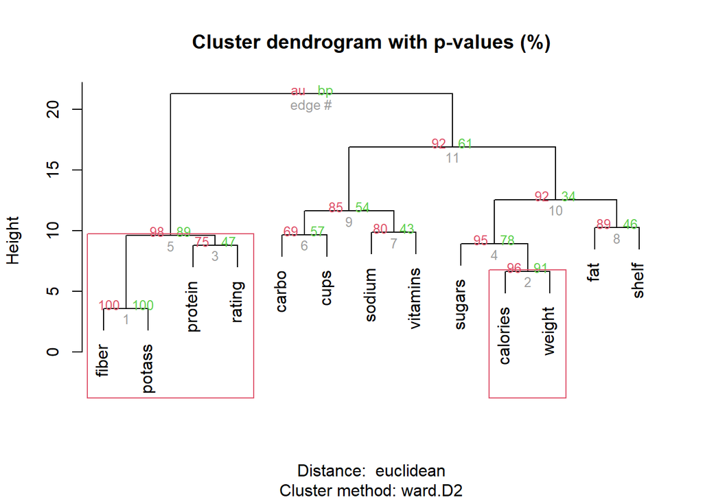

```r
plot(fit.pv) # dendogram with p values
# add rectangles around groups highly supported by the data
pvrect(fit.pv, alpha=.95)
```

The cluster stability of each cluster in the original clustering is the mean value of its Jaccard coefficient over all the bootstrap iterations. As a rule of thumb, clusters with a stability value less than 0.6 should be considered unstable. Values between 0.6 and 0.75 indicate that the cluster is measuring a pattern in the data, but there isn’t high certainty about which points should be clustered together. Clusters with stability values above about 0.85 can be considered highly stable

1. Clusterwise Jaccard bootstrap mean should be maximised
2. number of dissolved clusters should be minimised and
3. number of recovered clusters should be maximised and as close to the number of pre-defined bootstraps as possible

#Running clusterboot()

```r
library(fpc)
library(cluster)
kbest.p<-6
cboot.hclust <- clusterboot(cereals_data,clustermethod=hclustCBI,method="ward.D2", k=kbest.p)
```

```r
summary(cboot.hclust$result)
```

```
##               Length Class  Mode
## result         7     hclust list
## noise          1     -none- logical
## nc             1     -none- numeric
## clusterlist    6     -none- list
## partition     74     -none- numeric
## clustermethod  1     -none- character
## nccl           1     -none- numeric
```

```r
groups<-cboot.hclust$result$partition
head(data.frame(groups))
```

```
##                           groups
## 100%_Bran                      1
## 100%_Natural_Bran              2
## All-Bran                       1
## All-Bran_with_Extra_Fiber      1
## Apple_Cinnamon_Cheerios        3
## Apple_Jacks                    3
```

```r
#The vector of cluster stabilities
cboot.hclust$bootmean
```

```
## [1] 0.9090000 0.5503833 0.9018073 0.6895386 0.6229021 0.6728166
```

```r
#The count of how many times each cluste was dissolved. By default clusterboot() runs 100 bootstrap iterations.
cboot.hclust$bootbrd
```

```
## [1] 10 54  0 35 28 40
```

Extracting the clusters found by hclust()

```r
groups <- cutree(hc_ward_cut, k = 6)
print_clusters <- function(labels, k) {
for(i in 1:k) {
print(paste("cluster", i))
print(cereals[labels==i,c("mfr","calories","protein","fat","sodium","fiber","carbo","sugars","potass","vitamins","rating")])
}
}
print_clusters(groups, 6)
```

```
## [1] "cluster 1"
##                           mfr calories protein fat sodium fiber carbo sugars
## 100%_Bran                   N       70       4   1    130    10     5      6
## All-Bran                    K       70       4   1    260     9     7      5
## All-Bran_with_Extra_Fiber   K       50       4   0    140    14     8      0
##                           potass vitamins   rating
## 100%_Bran                    280       25 68.40297
## All-Bran                     320       25 59.42551
## All-Bran_with_Extra_Fiber    330       25 93.70491
## [1] "cluster 2"
##                                   mfr calories protein fat sodium fiber carbo
## 100%_Natural_Bran                   Q      120       3   5     15   2.0   8.0
## Clusters                            G      110       3   2    140   2.0  13.0
## Cracklin'_Oat_Bran                  K      110       3   3    140   4.0  10.0
## Crispy_Wheat_&_Raisins              G      100       2   1    140   2.0  11.0
## Great_Grains_Pecan                  P      120       3   3     75   3.0  13.0
## Life                                Q      100       4   2    150   2.0  12.0
## Muesli_Raisins,_Dates,_&_Almonds    R      150       4   3     95   3.0  16.0
## Muesli_Raisins,_Peaches,_&_Pecans   R      150       4   3    150   3.0  16.0
## Quaker_Oat_Squares                  Q      100       4   1    135   2.0  14.0
## Raisin_Nut_Bran                     G      100       3   2    140   2.5  10.5
##                                   sugars potass vitamins   rating
## 100%_Natural_Bran                      8    135        0 33.98368
## Clusters                               7    105       25 40.40021
## Cracklin'_Oat_Bran                     7    160       25 40.44877
## Crispy_Wheat_&_Raisins                10    120       25 36.17620
## Great_Grains_Pecan                     4    100       25 45.81172
## Life                                   6     95       25 45.32807
## Muesli_Raisins,_Dates,_&_Almonds      11    170       25 37.13686
## Muesli_Raisins,_Peaches,_&_Pecans     11    170       25 34.13976
## Quaker_Oat_Squares                     6    110       25 49.51187
## Raisin_Nut_Bran                        8    140       25 39.70340
## [1] "cluster 3"
##                         mfr calories protein fat sodium fiber carbo sugars
## Apple_Cinnamon_Cheerios   G      110       2   2    180   1.5  10.5     10
## Apple_Jacks               K      110       2   0    125   1.0  11.0     14
## Cap'n'Crunch              Q      120       1   2    220   0.0  12.0     12
## Cinnamon_Toast_Crunch     G      120       1   3    210   0.0  13.0      9
## Cocoa_Puffs               G      110       1   1    180   0.0  12.0     13
## Corn_Pops                 K      110       1   0     90   1.0  13.0     12
```

[output cut: 111 more lines]

```
## Raisin_Squares              K       90       2   0      0     2    15      6
## Shredded_Wheat              N       80       2   0      0     3    16      0
## Shredded_Wheat_'n'Bran      N       90       3   0      0     4    19      0
## Shredded_Wheat_spoon_size   N       90       3   0      0     3    20      0
## Strawberry_Fruit_Wheats     N       90       2   0     15     3    15      5
##                           potass vitamins   rating
## Frosted_Mini-Wheats          100       25 58.34514
## Maypo                         95       25 54.85092
## Puffed_Rice                   15        0 60.75611
## Puffed_Wheat                  50        0 63.00565
## Raisin_Squares               110       25 55.33314
## Shredded_Wheat                95        0 68.23588
## Shredded_Wheat_'n'Bran       140        0 74.47295
## Shredded_Wheat_spoon_size    120        0 72.80179
## Strawberry_Fruit_Wheats       90       25 59.36399
```

Note***

Since there is no proper mention of measure/scaleto become a healty diet, I decided to choose clusters based on statistical values and rich in nutritional values to form a healthy diet and this is purely subjective.

To answer weather needed to be normalized or not? I would say no. When we normalize the data, the magnitude of the data would be lost and it will become very difficult for us to read and decide.

The clusters contain nutritionally rich, adequate and poor levels of the cereal diet. We grouped all the records in to 6 clusters, we will evaluate these clusters considering all the variables/factors.